# regression models w mice imputation

2025-01-24

### The dataset

Note: on may 5, 2025: I made a few changes on some scales, based on more painstakingly reviewing model assumptions for EFA. These changes are reflected in paper I worked with Seth.

```r
d <- read_sav(here("outcomes paper/data_outcomes", "p_y_w1_for_analysesjan25_2.sav")) # 94 rows

view_df(d)
```

Data frame: d

| ID | Name | Label | Values | Value Labels |
| --- | --- | --- | --- | --- |
| 1 | school_id |  | *range: 1-6* |  |
| 2 | condition |  | *range: 1-2* |  |
| 3 | wave |  | *range: 1-1* |  |
| 4 | family_id | Family ID - PJ - Text |  | <output omitted> |
| 5 | participant_id |  |  | <output omitted> |
| 6 | parent_role |  | 1 2 3 | 1 2 4 |
| 7 | parent_role_text |  |  |  |
| 8 | parent_age |  | *range: 28-76* |  |
| 9 | country_born | ¿Dónde nació usted? - País: - Text |  | <output omitted> |
| 10 | age_arrival_us | ¿Cuántos años tenía cuando llegó a los E.U por primera vez? - Años: - Text |  | <output omitted> |
| 11 | white | Por favor, describa su raza / etnicidad: (marque los que correspondan): - Selected Choice Blanco | 1 | Blanco |
| 12 | latino | Por favor, describa su raza / etnicidad: (marque los que correspondan): - Selected Choice Hispano, Latino, o de Origen Español | 1 | Hispano, Latino, o de Origen Español |
| 13 | indigenous_lat_am | Por favor, describa su raza / etnicidad: (marque los que correspondan): - Selected Choice Indígena de México, Centro América o Sur América (especifiqué): | 1 | Indígena de México, Centro América o Sur América (especifiqué): |
| 14 | parent_ed |  | 1 2 3 4 | 1 2 3 4 |
| 15 | parent_eng_comf |  | 1 2 3 4 5 | 1 2 3 4 5 |
| 16 | h_lang_eng |  | *range: 0-1* |  |
| 17 | h_lang_spa |  | *range: 0-1* |  |
| 18 | h_lang_ind |  | *range: 0-1* |  |
| 19 | youth_age | Edad de su joven: - Edad: - Text |  | <output omitted> |
| 20 | youth_country_born | Lugar de nacimiento de su joven: - País: - Text |  | <output omitted> |
| 21 | adults_at_home | ¿Cuántas personas actualmente viven en su hogar incluyendo usted (las personas que comen y duermen allí la mayor parte del tiempo)? - Número de adultos (mayores de 18 años): - Text |  | <output omitted> |
| 22 | minors_at_home | ¿Cuántas personas actualmente viven en su hogar incluyendo usted (las personas que comen y duermen allí la mayor parte del tiempo)? - Número de niños (menores de 18 años): - Text |  | <output omitted> |
| 23 | lang_arts |  | *range: 1-5* |  |
| 24 | soc_stu |  | *range: 1-4* |  |
| 25 | math |  | *range: 1-5* |  |
| 26 | science |  | *range: 1-4* |  |
| 27 | gen_grades |  | *range: 1-6* |  |
| 28 | help_extra |  | *range: 0-1* |  |
| 29 | attend_pta |  | *range: 0-1* |  |
| 30 | sats_contact |  | *range: 1-4* |  |
| 31 | acadhwi_1 |  | *range: 1.0-4.0* |  |
| 32 | checkhwi_1 |  | *range: 1.0-4.0* |  |
| 33 | struct_1 |  | *range: 1.6-4.0* |  |
| 34 | trust_1 |  | *range: 2.6-4.0* |  |
| 35 | convclimate_1 |  | *range: 1.5-4.0* |  |
| 36 | convsocial_1 |  | *range: 1.5-4.0* |  |
| 37 | convfut_1 |  | *range: 1.0-4.0* |  |
| 38 | futorient_1 |  | *range: 2.8-4.0* |  |
| 39 | knowschool_1 |  | *range: 1.0-4.0* |  |
| 40 | parnets_1 |  | *range: 1.0-4.0* |  |
| 41 | stratsbi_1 |  | *range: 1.0-4.0* |  |
| 42 | selfeffic_1 |  | *range: 2.2-4.0* |  |
| 43 | welcome_1 |  | *range: 2.2-4.0* |  |
| 44 | included_1 |  | *range: 1.0-4.0* |  |
| 45 | endorse_1 |  | *range: 2.0-4.0* |  |
| 46 | endorse2_1 |  | *range: 2.0-4.0* |  |
| 47 | supported_1 |  | *range: 2.0-4.0* |  |
| 48 | ptrel_1 |  | *range: 2.0-4.0* |  |
| 49 | grade_lev |  | *range: 1-3* |  |
| 50 | grades |  | *range: 1-7* |  |
| 51 | y_homel_eng |  | *range: 1-1* |  |
| 52 | y_homel_spa |  | *range: 1-1* |  |
| 53 | youth_eng_comf |  | *range: 2-5* |  |
| 54 | youth_gender |  | *range: 1-2* |  |
| 55 | y_latino |  | *range: 1-1* |  |
| 56 | y_indigenous_americas |  | *range: 1-1* |  |
| 57 | y_race_ethnicity_no_response |  | *range: 1-1* |  |
| 58 | y_sch_eng |  | *range: 2.3-5.0* |  |
| 59 | y_parsupp |  | *range: 1.8-4.0* |  |
| 60 | y_parinv |  | *range: 1.0-4.0* |  |
| 61 | y_hw |  | *range: 1.3-4.0* |  |

```r
d1 <- d %>%
  select(school_id, family_id, participant_id, parent_eng_comf, youth_age, youth_gender, acadhwi_1, checkhwi_1, checkhwi_1, struct_1, convfut_1, knowschool_1, selfeffic_1, stratsbi_1, welcome_1, endorse2_1, supported_1, ptrel_1, y_sch_eng, y_parsupp, y_parinv, y_hw, gen_grades, grades)

view_df(d1)
```

Data frame: d1

| ID | Name | Label | Values | Value Labels |
| --- | --- | --- | --- | --- |
| 1 | school_id |  | *range: 1-6* |  |
| 2 | family_id | Family ID - PJ - Text |  | <output omitted> |
| 3 | participant_id |  |  | <output omitted> |
| 4 | parent_eng_comf |  | 1 2 3 4 5 | 1 2 3 4 5 |
| 5 | youth_age | Edad de su joven: - Edad: - Text |  | <output omitted> |
| 6 | youth_gender |  | *range: 1-2* |  |
| 7 | acadhwi_1 |  | *range: 1.0-4.0* |  |
| 8 | checkhwi_1 |  | *range: 1.0-4.0* |  |
| 9 | struct_1 |  | *range: 1.6-4.0* |  |
| 10 | convfut_1 |  | *range: 1.0-4.0* |  |
| 11 | knowschool_1 |  | *range: 1.0-4.0* |  |
| 12 | selfeffic_1 |  | *range: 2.2-4.0* |  |
| 13 | stratsbi_1 |  | *range: 1.0-4.0* |  |
| 14 | welcome_1 |  | *range: 2.2-4.0* |  |
| 15 | endorse2_1 |  | *range: 2.0-4.0* |  |
| 16 | supported_1 |  | *range: 2.0-4.0* |  |
| 17 | ptrel_1 |  | *range: 2.0-4.0* |  |
| 18 | y_sch_eng |  | *range: 2.3-5.0* |  |
| 19 | y_parsupp |  | *range: 1.8-4.0* |  |
| 20 | y_parinv |  | *range: 1.0-4.0* |  |
| 21 | y_hw |  | *range: 1.3-4.0* |  |
| 22 | gen_grades |  | *range: 1-6* |  |
| 23 | grades |  | *range: 1-7* |  |

```r
d2 <- d1 %>%
  mutate(parent_eng_comf = as.numeric(parent_eng_comf),
         youth_gender = factor(youth_gender),
         youth_age = as.numeric(youth_age))
# View(d2)
# view_df(d2)
```

# descriptive stats function

```r
descrip_table <- descriptives(d2) %>%
  rename(c("Scale" = "column"))

descrip_table
```

```
## # A tibble: 20 × 8
##    Scale               n n_valid    na     M    SD   Min   Max
##    <chr>           <int>   <int> <int> <dbl> <dbl> <dbl> <dbl>
##  1 school_id          94      94     0  3.64  1.75  1        6
##  2 parent_eng_comf    94      86     8  2.73  1.37  1        5
##  3 youth_age          94      93     1 12.0   0.81 10       13
##  4 acadhwi_1          94      93     1  2.71  0.67  1        4
##  5 checkhwi_1         94      93     1  3.58  0.66  1        4
##  6 struct_1           94      94     0  2.94  0.43  1.62     4
##  7 convfut_1          94      94     0  3.23  0.72  1        4
##  8 knowschool_1       94      94     0  2.95  0.52  1        4
##  9 selfeffic_1        94      94     0  3.12  0.39  2.2      4
## 10 stratsbi_1         94      94     0  2.65  0.51  1        4
## 11 welcome_1          94      94     0  3.15  0.41  2.25     4
## 12 endorse2_1         94      94     0  3.16  0.4   2        4
## 13 supported_1        94      94     0  3.15  0.4   2        4
## 14 ptrel_1            94      94     0  3.07  0.46  2        4
## 15 y_sch_eng          94      94     0  4.03  0.52  2.33     5
## 16 y_parsupp          94      94     0  3.12  0.6   1.8      4
## 17 y_parinv           94      94     0  2.78  0.72  1        4
## 18 y_hw               94      94     0  3.2   0.45  1.33     4
## 19 gen_grades         94      91     3  2.26  1.08  1        6
## 20 grades             94      90     4  2.39  1.15  1        7
```

# Inspect missingness patterns

outcomes with no NA: y_sch_eng  
y_parsupp y_parinv  
y_hw selfeffic_1

predictors with no NA: youth_gender struct_1 convfut_1 knowschool_1 stratsbi_1 welcome_1 endorse2_1  
supported_1  
ptrel_1

This figure shows: 80 rows have no missing values 5 rows are missing parent_eng_comf 1 row is missing grades 3 rows are missing grades and parent_eng_comf 3 rows are missing gen_grades 1 row is missing acadhwi_1 and checkhwi_1 1 row is missing youth_age

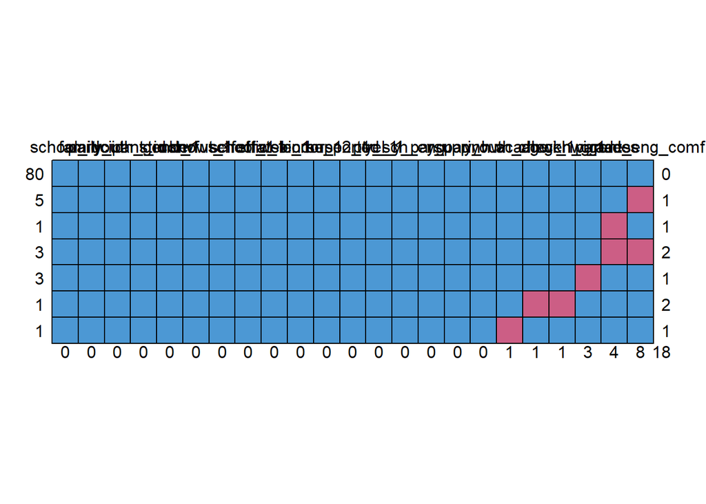

```
##    school_id family_id participant_id youth_gender struct_1 convfut_1
## 80         1         1              1            1        1         1
## 5          1         1              1            1        1         1
## 1          1         1              1            1        1         1
## 3          1         1              1            1        1         1
## 3          1         1              1            1        1         1
## 1          1         1              1            1        1         1
## 1          1         1              1            1        1         1
##            0         0              0            0        0         0
##    knowschool_1 selfeffic_1 stratsbi_1 welcome_1 endorse2_1 supported_1 ptrel_1
## 80            1           1          1         1          1           1       1
## 5             1           1          1         1          1           1       1
## 1             1           1          1         1          1           1       1
## 3             1           1          1         1          1           1       1
## 3             1           1          1         1          1           1       1
```

[output cut: 21 more lines]

```r
md.pattern(d2)
```

# Inspect missingness proportions

This plot shows proportion of missingness: 85% is not missing

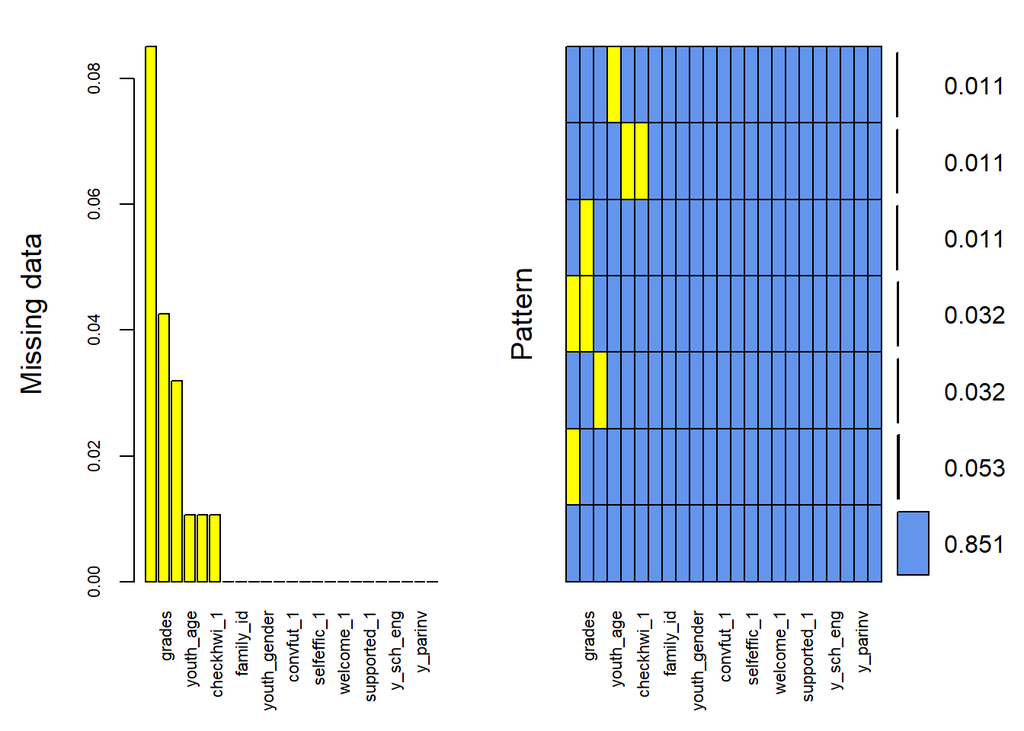

```
##
##  Variables sorted by number of missings:
##         Variable      Count
##  parent_eng_comf 0.08510638
##           grades 0.04255319
##       gen_grades 0.03191489
##        youth_age 0.01063830
##        acadhwi_1 0.01063830
##       checkhwi_1 0.01063830
##        school_id 0.00000000
##        family_id 0.00000000
##   participant_id 0.00000000
##     youth_gender 0.00000000
##         struct_1 0.00000000
##        convfut_1 0.00000000
##     knowschool_1 0.00000000
##      selfeffic_1 0.00000000
##       stratsbi_1 0.00000000
##        welcome_1 0.00000000
##       endorse2_1 0.00000000
##      supported_1 0.00000000
##          ptrel_1 0.00000000
##        y_sch_eng 0.00000000
##        y_parsupp 0.00000000
##         y_parinv 0.00000000
##             y_hw 0.00000000
```

```r
nice_plot <- aggr(d2, col = c ('cornflowerblue', 'yellow'),
                  numbers = TRUE, sortVars = TRUE,
                  labels = names (d2), cex.axis = .7,
                  gap = 4, ylab = c ("Missing data", "Pattern"))
```

# Create a missingness or margin plot to further inspect missingness

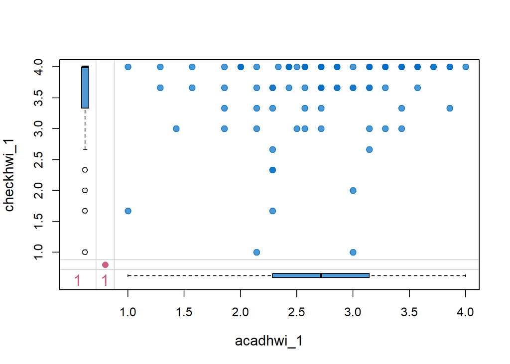

```r
marginplot(d2[, c("acadhwi_1", "checkhwi_1")], col = mdc(1:2), cex = 1.2, cex.lab = 1.2, cex.numbers = 1.3, pch = 19) # only 2 variables at a time
```

# Perform Little’s MCAR test

Get this error message: Error in TestMCARNormality(d2) :More than one missing data pattern should be present.

```r
library(RNOmni)  # Alternative package since BaylorEdPsych is unavailable
# TestMCARNormality(d2)
```

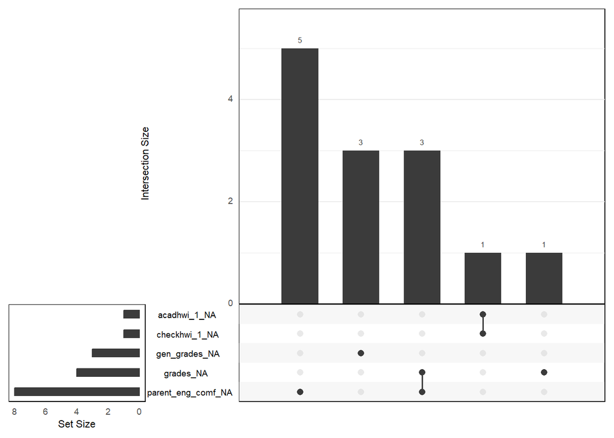

```r
library(naniar)
gg_miss_upset(d2)
```

### Imputation preprocessing

Following this instructions: https://library.virginia.edu/data/articles/getting-started-with-multiple-imputation-in-r

This person suggest to remove variables that have more than 25% misingness, character variables, and to remove variables that are highly correlated with others as that might mess up the imputations. Also they suggest not make any transformations at this point.

# Specify a separate imputation model for variables of interest is they are not numerical (code from link above)

# Ordered categorical variables

poly <- c(“patriot_amident”, “pid_x”)

# Dichotomous variable

log <- c(“manuf”)

# Unordered categorical variable

poly2 <- c(“china_econ”)

meth[poly] <- “polr” meth[log] <- “logreg” meth[poly2] <- “polyreg”

```r
d3 <- d2 %>%
  select(-school_id, -family_id, -participant_id)

# view_df(d3)

#str(d3) # all except gender (factor) are numerical variables.
```

### Imputation

```r
# We run the mice code with 0 iterations
imp <- mice(d3, maxit=0)

# Extract predictorMatrix and methods of imputation
predM <- imp$predictorMatrix
meth <- imp$method # Empty cells in the method matrix mean those variables will not be imputed

head(predM)
```

```
##                 parent_eng_comf youth_age youth_gender acadhwi_1 checkhwi_1
## parent_eng_comf               0         1            1         1          1
## youth_age                     1         0            1         1          1
## youth_gender                  1         1            0         1          1
## acadhwi_1                     1         1            1         0          1
## checkhwi_1                    1         1            1         1          0
## struct_1                      1         1            1         1          1
##                 struct_1 convfut_1 knowschool_1 selfeffic_1 stratsbi_1
## parent_eng_comf        1         1            1           1          1
## youth_age              1         1            1           1          1
## youth_gender           1         1            1           1          1
## acadhwi_1              1         1            1           1          1
## checkhwi_1             1         1            1           1          1
## struct_1               0         1            1           1          1
##                 welcome_1 endorse2_1 supported_1 ptrel_1 y_sch_eng y_parsupp
## parent_eng_comf         1          1           1       1         1         1
## youth_age               1          1           1       1         1         1
## youth_gender            1          1           1       1         1         1
## acadhwi_1               1          1           1       1         1         1
## checkhwi_1              1          1           1       1         1         1
## struct_1                1          1           1       1         1         1
##                 y_parinv y_hw gen_grades grades
## parent_eng_comf        1    1          1      1
## youth_age              1    1          1      1
## youth_gender           1    1          1      1
## acadhwi_1              1    1          1      1
## checkhwi_1             1    1          1      1
## struct_1               1    1          1      1
```